# Лабораторная работа №8

Основы информационной безопасности

Верниковская Е. А., НПИбд-01-23

Российский университет дружбы народов, Москва, Россия

29 мая 2025

# Вводная часть

## Цель работы

Целью данной работы является освоение на практике применения режима однократного гаммирования напримере кодирования различных исходных текстов одним ключом.

## Задание

Два текста кодируются одним ключом (однократное гаммирование). Требуется не зная ключа и не стремясь его определить, прочитать оба текста. Необходимо разработать приложение, позволяющее шифровать и дешифровать тексты P1 и P2 в режиме однократного гаммирования. Приложение должно определить вид шифротекстов C1 и C2 обоих текстов P1 и P2 при известном ключе; Необходимо определить и выразить аналитически способ, при котором злоумышленник может прочитать оба текста, не зная ключа и не стремясь его определить.

# Выполнение лабораторной работы

## Выполнение лабораторной работы

Выполним лабораторную работу на языке программирования Python, используя ранее написанные функции при выполнении лабораторной работы №7 (рис. 1)

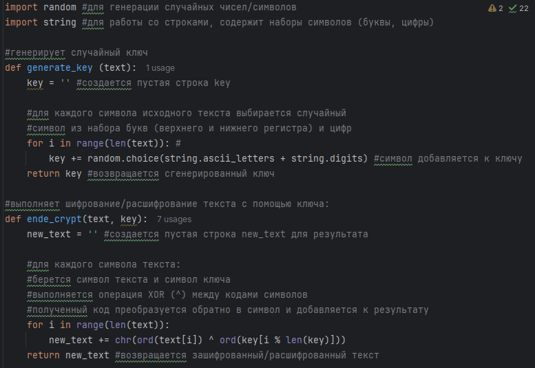

Функции

## Выполнение лабораторной работы

Далее, используя функцию для генерации числа, сгенирируем ключ, затем зашифруем 2 разных текста одним и тем же ключом (рис. 2)

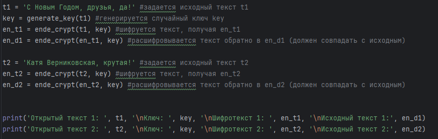

Шифрование двух текстов

## Выполнение лабораторной работы

Расшифруем оба текста сначала с помощью одного ключа, а затем предположим, что нам не известен ключ, но известен один из текстов. И расшифруем второй текст, зная только шифротексты и первый текст (рис. 3), (рис. 4)

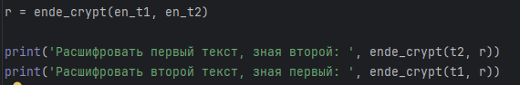

Расшифровка текстов, без ключа

## Выполнение лабораторной работы

[figure not shown]

Результат работы программы

# Подведение итогов

## Выводы

В результате выполнения работы мы освоили на практике применение режима однократного гаммирования на примере кодирования различных исходных текстов одним ключом

## Список литературы

1. Лаборатораня работа №8 [Электронный ресурс] URL: https://esystem.rudn.ru/pluginfile.php/2580990/mod_resource/content/2/008-lab_crypto-key.pdf